# ENGESAETH_MariaAthena_hw2_bondsdata

## Contents of iPython Notebook

Assignment 2 for Advanced Analytics and Machine Learning: Unsupervised Learning of Corporate and Municipal Bonds Datasets

```
* Part I   - Preprocessing of bond data
* Part II  - K-means clustering of bond data
* Part III - Hierarchical clustering of bond data
```

by Maria Athena B Engesaeth

```python
%%javascript
IPython.OutputArea.auto_scroll_threshold = 9999;
```

```python
# Setting up the environment
%pylab inline
%matplotlib inline
#import numpy as np
#import matplotlib.pyplot as plt
import matplotlib.cm as cm

import pandas as pd
import seaborn as sns

import sklearn
from sklearn import cluster
from sklearn.metrics import silhouette_samples, silhouette_score
from sklearn.decomposition import PCA

from scipy.spatial.distance import cdist
from scipy.cluster.hierarchy import dendrogram, linkage
```

## Part I - Preprocessing of bond data

### Q1: Load and prepare data

```python
# Filepaths
CorporateBond = '/Users/mariaathena/Dropbox (Personal)/00 Imperial College/1601 Machine Learning/Assignment 2/Data (csv)/CorporateBond.csv'
MunicipalBond = '/Users/mariaathena/Dropbox (Personal)/00 Imperial College/1601 Machine Learning/Assignment 2/Data (csv)/MunicipalBond.csv'
stockreturn2 = '/Users/mariaathena/Dropbox (Personal)/00 Imperial College/1601 Machine Learning/Assignment 2/Data (csv)/stockreturn2.csv'

corp_df = pd.DataFrame.from_csv(CorporateBond)
muni_df = pd.DataFrame.from_csv(MunicipalBond)
stock_df = pd.DataFrame.from_csv(stockreturn2)
```

```python
muni_df.columns
```

```
Index([u'Price', u'Coupon', u'Maturity', u'YTM', u'CurrentYield', u'Rating'], dtype='object')
```

```python
# Take Rating strings out of quotations
corp_df.Rating = corp_df['Rating'].apply(lambda x: x.replace("'", ""))
muni_df.Rating = muni_df['Rating'].apply(lambda x: x.replace("'", ""))
```

```python
# Convert Maturity field from string to timeseries and set as index
corp_df.Maturity = pd.to_datetime(corp_df.Maturity, dayfirst=True).dt.date
corp_df.set_index(['Maturity'], inplace=True)
corp_df.sort_index(inplace=True)
# EXCLUDE(!) datapoint from YYYY = 2098 -> assumed error
corp_df.drop(corp_df.index[-1], inplace=True)

muni_df.Maturity = pd.to_datetime(muni_df.Maturity, dayfirst=True).dt.date
muni_df.set_index(['Maturity'], inplace=True)
muni_df.sort_index(inplace=True)
```

```python
# Create dummy variable columns of Rating field
corp_df = pd.concat([corp_df, pd.get_dummies(corp_df.Rating, prefix='Rating_')], axis=1)
muni_df = pd.concat([muni_df, pd.get_dummies(muni_df.Rating, prefix='Rating_')], axis=1)
#corp_df.Rating = pd.Categorical(corp_df.Rating, categories=['AAA', 'AA', 'A', 'BBB', 'BB', 'B', 'CCC'], ordered=True)
#muni_df.Rating = pd.Categorical(muni_df.Rating, categories=['AAA', 'AA', 'A', 'BBB', 'BB', 'B', 'CCC'], ordered=True)
```

```python
# Change Order of that Ratings_ appear
corp_df = corp_df[['Price', 'Coupon', 'YTM', 'CurrentYield', 'Rating', 'Rating__AAA', 'Rating__AA', 'Rating__A', 'Rating__BBB', 'Rating__BB', 'Rating__B', 'Rating__CCC', 'Rating__CC']]
muni_df = muni_df[['Price', 'Coupon', 'YTM', 'CurrentYield', 'Rating', 'Rating__AAA', 'Rating__AA', 'Rating__A', 'Rating__BBB']]
#corp_df.columns.tolist()
```

```python
# Descriptive statistics of the Corporate Bond data
corp_df.describe().T
```

|  | count | mean | std | min | 25% | 50% | 75% | max |
| --- | --- | --- | --- | --- | --- | --- | --- | --- |
| Price | 350.0 | 108.414629 | 14.374282 | 40.510000 | 102.065000 | 107.285000 | 115.232500 | 155.840000 |
| Coupon | 350.0 | 5.559886 | 2.040533 | 0.880000 | 4.467500 | 5.705000 | 6.840000 | 12.400000 |
| YTM | 350.0 | 4.066557 | 1.480426 | 0.728000 | 3.288500 | 4.040500 | 4.839000 | 10.193000 |
| CurrentYield | 350.0 | 5.259832 | 2.486812 | 0.862322 | 4.006467 | 5.156358 | 6.385986 | 25.351765 |
| Rating__AAA | 350.0 | 0.205714 | 0.404801 | 0.000000 | 0.000000 | 0.000000 | 0.000000 | 1.000000 |
| Rating__AA | 350.0 | 0.117143 | 0.322051 | 0.000000 | 0.000000 | 0.000000 | 0.000000 | 1.000000 |
| Rating__A | 350.0 | 0.280000 | 0.449642 | 0.000000 | 0.000000 | 0.000000 | 1.000000 | 1.000000 |
| Rating__BBB | 350.0 | 0.202857 | 0.402703 | 0.000000 | 0.000000 | 0.000000 | 0.000000 | 1.000000 |
| Rating__BB | 350.0 | 0.082857 | 0.276061 | 0.000000 | 0.000000 | 0.000000 | 0.000000 | 1.000000 |
| Rating__B | 350.0 | 0.082857 | 0.276061 | 0.000000 | 0.000000 | 0.000000 | 0.000000 | 1.000000 |
| Rating__CCC | 350.0 | 0.025714 | 0.158508 | 0.000000 | 0.000000 | 0.000000 | 0.000000 | 1.000000 |
| Rating__CC | 350.0 | 0.002857 | 0.053452 | 0.000000 | 0.000000 | 0.000000 | 0.000000 | 1.000000 |

```python
# Count of Ratings in CorporateBonds
#temp_df = corp_df.drop(corp_df.columns[[0, 1, 2, 3]], axis=1)
#temp_df.groupby('Rating').sum()
```

```python
# Descriptive statistics of the Municipal Bond data
muni_df.describe().T
```

|  | count | mean | std | min | 25% | 50% | 75% | max |
| --- | --- | --- | --- | --- | --- | --- | --- | --- |
| Price | 32.0 | 110.621250 | 15.375905 | 36.6300 | 108.817500 | 111.900000 | 116.985000 | 136.090000 |
| Coupon | 32.0 | 4.716250 | 1.152856 | 0.0300 | 4.280000 | 4.975000 | 5.137500 | 6.650000 |
| YTM | 32.0 | 3.477719 | 0.869377 | 0.1130 | 3.268500 | 3.718500 | 3.997750 | 4.563000 |
| CurrentYield | 32.0 | 4.175070 | 0.977203 | 0.0819 | 3.961095 | 4.343747 | 4.595256 | 5.777898 |
| Rating__AAA | 32.0 | 0.125000 | 0.336011 | 0.0000 | 0.000000 | 0.000000 | 0.000000 | 1.000000 |
| Rating__AA | 32.0 | 0.531250 | 0.507007 | 0.0000 | 0.000000 | 1.000000 | 1.000000 | 1.000000 |
| Rating__A | 32.0 | 0.281250 | 0.456803 | 0.0000 | 0.000000 | 0.000000 | 1.000000 | 1.000000 |
| Rating__BBB | 32.0 | 0.062500 | 0.245935 | 0.0000 | 0.000000 | 0.000000 | 0.000000 | 1.000000 |

```python
# Count of Ratings in CorporateBonds
#temp_df2 = muni_df.drop(muni_df.columns[[0, 1, 2, 3]], axis=1)
#temp_df2.groupby('Rating').sum()
```

The above tables display descriptive statistics for each feature in two datasets of Corporate and Municipal Bonds. I have chosen to visualise and then clustering the datapoints based on the features: Coupon Rate and YTM.

Price was ruled out as the spread in the values are very large and would end up having a disproportionate effect on the other variables.

### Q2: Visualising the data

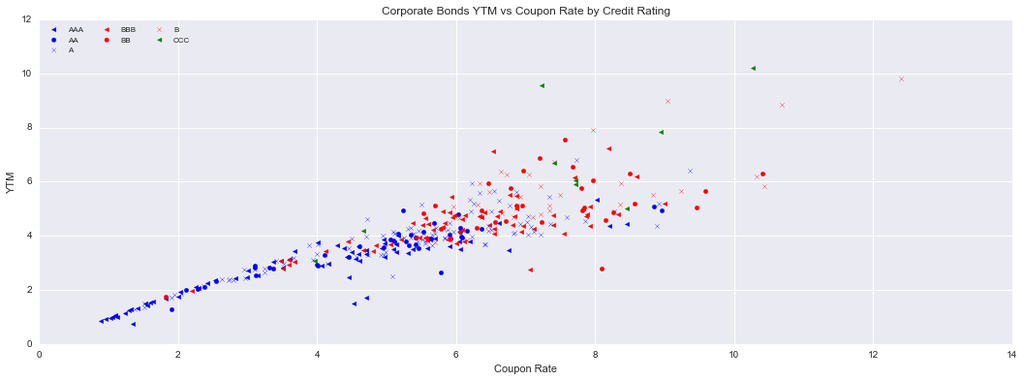

```python
# Visualisation of the Corporate Bonds Data
# YTM vs Coupon Rate by Credit Rating

fig = plt.figure(figsize=(18,6), dpi=1600)
alpha=alpha_scatterplot = 0.5
colors = ['b', 'r', 'g']

## A Rated bonds
corp_AAA = plt.scatter(corp_df.Coupon[corp_df.Rating == 'AAA'], corp_df.YTM[corp_df.Rating == 'AAA'],
                       marker='<', color=colors[0])
corp_AA = plt.scatter(corp_df.Coupon[corp_df.Rating == 'AA'], corp_df.YTM[corp_df.Rating == 'AA'],
                       marker='o', color=colors[0])
corp_A = plt.scatter(corp_df.Coupon[corp_df.Rating == 'A'], corp_df.YTM[corp_df.Rating == 'A'],
                       marker='x', color=colors[0])
## B Rated bonds
corp_BBB = plt.scatter(corp_df.Coupon[corp_df.Rating == 'BBB'], corp_df.YTM[corp_df.Rating == 'BBB'],
                       marker='<', color=colors[1])
corp_BB = plt.scatter(corp_df.Coupon[corp_df.Rating == 'BB'], corp_df.YTM[corp_df.Rating == 'BB'],
                       marker='o', color=colors[1])
corp_B = plt.scatter(corp_df.Coupon[corp_df.Rating == 'B'], corp_df.YTM[corp_df.Rating == 'B'],
                       marker='x', color=colors[1])
## C Rated bonds
corp_CCC = plt.scatter(corp_df.Coupon[corp_df.Rating == 'CCC'], corp_df.YTM[corp_df.Rating == 'CCC'],
                       marker='<', color=colors[2])


plt.legend((corp_AAA, corp_AA, corp_A, corp_BBB, corp_BB, corp_B, corp_CCC),
           ('AAA', 'AA', 'A', 'BBB', 'BB', 'B', 'CCC'),
           scatterpoints=1,
           loc='upper left',
           ncol=3,
           fontsize=8)

plt.xlabel("Coupon Rate")
plt.ylabel("YTM")
plt.title("Corporate Bonds YTM vs Coupon Rate by Credit Rating")

plt.show()
```

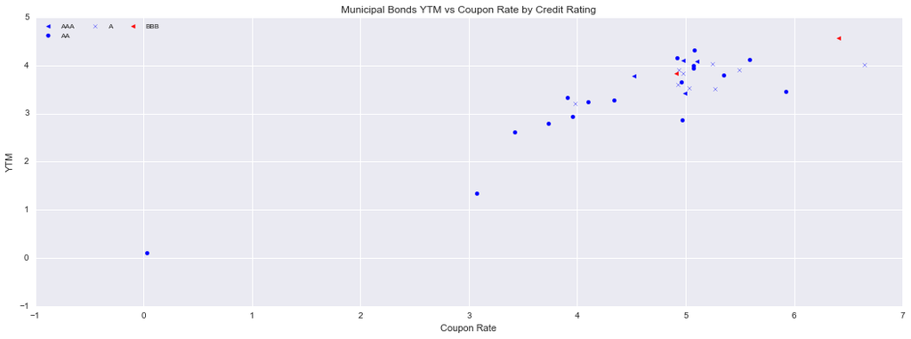

```python
# Visualisation of the Corporate Bonds Data
# YTM vs Coupon Rate by Credit Rating

fig = plt.figure(figsize=(18,6), dpi=1600)
alpha=alpha_scatterplot = 0.5
colors = ['b', 'r']

## A Rated bonds
muni_AAA = plt.scatter(muni_df.Coupon[muni_df.Rating == 'AAA'], muni_df.YTM[muni_df.Rating == 'AAA'],
                       marker='<', color=colors[0])
muni_AA = plt.scatter(muni_df.Coupon[muni_df.Rating == 'AA'], muni_df.YTM[muni_df.Rating == 'AA'],
                       marker='o', color=colors[0])
muni_A = plt.scatter(muni_df.Coupon[muni_df.Rating == 'A'], muni_df.YTM[muni_df.Rating == 'A'],
                       marker='x', color=colors[0])
## B Rated bonds
muni_BBB = plt.scatter(muni_df.Coupon[muni_df.Rating == 'BBB'], muni_df.YTM[muni_df.Rating == 'BBB'],
                       marker='<', color=colors[1])


plt.legend((muni_AAA, muni_AA, muni_A, muni_BBB),
           ('AAA', 'AA', 'A', 'BBB'),
           scatterpoints=1,
           loc='upper left',
           ncol=3,
           fontsize=8)

plt.xlabel("Coupon Rate")
plt.ylabel("YTM")
plt.title("Municipal Bonds YTM vs Coupon Rate by Credit Rating")

plt.show()
```

```python
# Plot density estimate of the subset of the Prices by bonds CurrentYield

#fig = plt.figure(figsize=(18,6), dpi=1600)

#corp_df.CurrentYield[corp_df.Rating == 'AAA'].plot(kind='kde')
#corp_df.CurrentYield[corp_df.Rating == 'AA'].plot(kind='kde')
#corp_df.CurrentYield[corp_df.Rating == 'A'].plot(kind='kde')
#corp_df.CurrentYield[corp_df.Rating == 'BBB'].plot(kind='kde')
#corp_df.CurrentYield[corp_df.Rating == 'BB'].plot(kind='kde')
#corp_df.CurrentYield[corp_df.Rating == 'B'].plot(kind='kde')
#corp_df.CurrentYield[corp_df.Rating == 'CCC'].plot(kind='kde')
##corp_df.CurrentYield[corp_df.Rating == 'CC'].plot(kind='kde') #Only contains 1 datapoint
#plt.xlabel("CurrentYield")
#plt.title("CurrentYield Distribution within Ratings")
# Set legend for graph
#plt.legend(('AAA', 'AA','A', 'BBB', 'BB', 'B', 'CCC'),loc='best')
```

#### Bonus Questions

The features (YTM and Coupon Rate) were chosen as the standard deviation was at a reasonable level compared to their mean values. This is important as k-means can be sensitive to outliers and would thus have an adverse effect on our attempt to cluster the bonds.

The same features were chosen for Corporate and Municipal bonds as the data looked reasonably similar for their means and standard deviation.

## PART II: K-means clustering of bond data

### Q1: Bubbleplots - Visualise K-Means Clusters

#### Corporate Bonds Dataset

```python
# Corporate Bonds Dataset
# Convert the two features Coupon and YTM to numpy array
c_data = np.array(corp_df[['Coupon', 'YTM']])
#X = data[:,1:] # Coupon Rate values
#y = data[:,0] # YTM values

# Set the distance metric -> ??
#eucl_data = cdist(c_data, c_data, metric='euclidean')
```

```python
# Compute the K-Means cluster for the Corporate Bonds Data Set

# K-Means for k=2
n_clusters2=2
k_means2 = cluster.KMeans(n_clusters=n_clusters2, init='k-means++')
k_means2.fit(c_data) # Computes k-means

k_means_labels2 = k_means2.labels_
centroids2 = k_means2.cluster_centers_
k_means_labels_unique2 = np.unique(k_means_labels2)


# K-Means for k=3
n_clusters3=3
k_means3 = cluster.KMeans(n_clusters=n_clusters3, init='k-means++')
k_means3.fit(c_data) # Computes k-means

k_means_labels3 = k_means3.labels_
centroids3 = k_means3.cluster_centers_
k_means_labels_unique3 = np.unique(k_means_labels3)
```

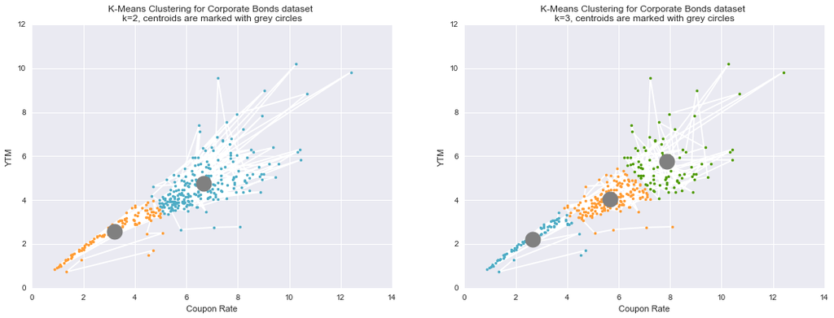

```python
# Plot result
fig = plt.figure(figsize=(18,6), dpi=1600)
#fig.subplots_adjust(left=0.02, right=0.98, bottom=0.05, top=0.9)

colors2 = ['#4EACC5', '#FF9C34']
colors3 = ['#4EACC5', '#FF9C34', '#4E9A06']


# KMeans, k=2
ax2 = fig.add_subplot(1, 2, 1) # rows, columns, plot nb.
for k, col in zip(range(n_clusters2), colors2):
    my_members2 = k_means_labels2 == k
    cluster_center2 = centroids2[k]
    ax2.plot(c_data[my_members2, 0], c_data[my_members2, 1], 'w',
            markerfacecolor=col, marker='.')
    ax2.plot(cluster_center2[0], cluster_center2[1], 'o', markerfacecolor='grey',
            markeredgecolor='w', markersize=20)
ax2.set_title('K-Means Clustering for Corporate Bonds dataset \n'
             'k=2, centroids are marked with grey circles')
plt.xlabel("Coupon Rate")
plt.ylabel("YTM")


# KMeans, k=3
ax3 = fig.add_subplot(1, 2, 2)
for k, col in zip(range(n_clusters3), colors3):
    my_members3 = k_means_labels3 == k
    cluster_center3 = centroids3[k]
    ax3.plot(c_data[my_members3, 0], c_data[my_members3, 1], 'w',
            markerfacecolor=col, marker='.')
    ax3.plot(cluster_center3[0], cluster_center3[1], 'o', markerfacecolor='grey',
            markeredgecolor='w', markersize=20)
ax3.set_title('K-Means Clustering for Corporate Bonds dataset \n'
             'k=3, centroids are marked with grey circles')
plt.xlabel("Coupon Rate")
plt.ylabel("YTM")

#plt.show()
```

#### Municipal Bonds Dataset

```python
# Municipal Bonds Dataset
# Convert the two features Coupon and YTM to numpy array
m_data = np.array(muni_df[['Coupon', 'YTM']])
#X = data[:,1:] # Coupon Rate values
#y = data[:,0] # YTM values

# Set the distance metric -> unsure??
#eucl_data = cdist(m_data, m_data, metric='euclidean')
```

```python
# Compute the K-Means cluster for the Corporate Bonds Data Set

# K-Means for k=2
n_clusters2=2
k_means2 = cluster.KMeans(n_clusters=n_clusters2, init='k-means++')
k_means2.fit(m_data) # Computes k-means

k_means_labels2 = k_means2.labels_
centroids2 = k_means2.cluster_centers_
k_means_labels_unique2 = np.unique(k_means_labels2)


# K-Means for k=3
n_clusters3=3
k_means3 = cluster.KMeans(n_clusters=n_clusters3, init='k-means++')
k_means3.fit(m_data) # Computes k-means

k_means_labels3 = k_means3.labels_
centroids3 = k_means3.cluster_centers_
k_means_labels_unique3 = np.unique(k_means_labels3)
```

[figure not shown]

```python
# Plot result
fig = plt.figure(figsize=(18,6), dpi=1600)
#fig.subplots_adjust(left=0.02, right=0.98, bottom=0.05, top=0.9)

colors2 = ['#4EACC5', '#FF9C34']
colors3 = ['#4EACC5', '#FF9C34', '#4E9A06']


# KMeans, k=2
ax2 = fig.add_subplot(1, 2, 1) # rows, columns, plot nb.
for k, col in zip(range(n_clusters2), colors2):
    my_members2 = k_means_labels2 == k
    cluster_center2 = centroids2[k]
    ax2.plot(c_data[my_members2, 0], c_data[my_members2, 1], 'w',
            markerfacecolor=col, marker='.')
    ax2.plot(cluster_center2[0], cluster_center2[1], 'o', markerfacecolor='grey',
            markeredgecolor='w', markersize=20)
ax2.set_title('K-Means Clustering for Municipal Bonds dataset \n'
             'k=2, centroids are marked with grey circles')
plt.xlabel("Coupon Rate")
plt.ylabel("YTM")


# KMeans, k=3
ax3 = fig.add_subplot(1, 2, 2)
for k, col in zip(range(n_clusters3), colors3):
    my_members3 = k_means_labels3 == k
    cluster_center3 = centroids3[k]
    ax3.plot(m_data[my_members3, 0], m_data[my_members3, 1], 'w',
            markerfacecolor=col, marker='.')
    ax3.plot(cluster_center3[0], cluster_center3[1], 'o', markerfacecolor='grey',
            markeredgecolor='w', markersize=20)
ax3.set_title('K-Means Clustering for Municipal Bonds dataset \n'
             'k=3, centroids are marked with grey circles')
plt.xlabel("Coupon Rate")
plt.ylabel("YTM")

plt.show()
```

I chose to the Euclidean distance metrics as it is the only one possible to use with the sklearn package. Above are the plots generated for each data set when k is set to 2 and 3.

### Q2: Cluster Silhouette Score

#### Corporate Bonds Dataset

```python
# Convert the two features Coupon and YTM to numpy array
c_data = np.array(corp_df[['Coupon', 'YTM']])

# Loop through values for k ranging from 1 to 10 to calcualte the silhouette score
range_n_clusters = [2, 3, 4, 5, 6, 7, 8, 9, 10]

for n_clusters in range_n_clusters:
    # Initialize the clusterer with n_clusters value and a random generator
    # seed of 10 for reproducibility.
    clusterer = sklearn.cluster.KMeans(n_clusters=n_clusters, random_state=10)
    cluster_labels = clusterer.fit_predict(c_data)

    # The silhouette_score gives the average value for all the samples.
    # This gives a perspective into the density and separation of the formed
    # clusters
    silhouette_avg = sklearn.metrics.silhouette_score(c_data, cluster_labels)
    print("For n_clusters =", n_clusters,
          "The average silhouette_score is :", silhouette_avg)
```

```
('For n_clusters =', 2, 'The average silhouette_score is :', 0.5143756652055822)
('For n_clusters =', 3, 'The average silhouette_score is :', 0.47987122876673816)
('For n_clusters =', 4, 'The average silhouette_score is :', 0.42630914540504772)
('For n_clusters =', 5, 'The average silhouette_score is :', 0.43069643581283712)
('For n_clusters =', 6, 'The average silhouette_score is :', 0.42653593702679937)
('For n_clusters =', 7, 'The average silhouette_score is :', 0.42555436118407947)
('For n_clusters =', 8, 'The average silhouette_score is :', 0.40678782536294811)
('For n_clusters =', 9, 'The average silhouette_score is :', 0.40114656265450815)
('For n_clusters =', 10, 'The average silhouette_score is :', 0.38242066732710911)
```

#### Municipal Bonds Dataset

```python
# Convert the two features Coupon and YTM to numpy array
m_data = np.array(muni_df[['Coupon', 'YTM']])

# Loop through values for k ranging from 1 to 10 to calcualte the silhouette score
range_n_clusters = [2, 3, 4, 5, 6, 7, 8, 9, 10]

for n_clusters in range_n_clusters:
    # Initialize the clusterer with n_clusters value and a random generator
    # seed of 10 for reproducibility.
    clusterer = sklearn.cluster.KMeans(n_clusters=n_clusters, random_state=10)
    cluster_labels = clusterer.fit_predict(m_data)

    # The silhouette_score gives the average value for all the samples.
    # This gives a perspective into the density and separation of the formed
    # clusters
    silhouette_avg = sklearn.metrics.silhouette_score(m_data, cluster_labels)
    print("For n_clusters =", n_clusters,
          "The average silhouette_score is :", silhouette_avg)
```

```
('For n_clusters =', 2, 'The average silhouette_score is :', 0.62612309235678032)
('For n_clusters =', 3, 'The average silhouette_score is :', 0.59147871378588968)
('For n_clusters =', 4, 'The average silhouette_score is :', 0.5786173812295613)
('For n_clusters =', 5, 'The average silhouette_score is :', 0.58323470957806489)
('For n_clusters =', 6, 'The average silhouette_score is :', 0.46514657370188395)
('For n_clusters =', 7, 'The average silhouette_score is :', 0.47130707550737955)
('For n_clusters =', 8, 'The average silhouette_score is :', 0.45863977567016784)
('For n_clusters =', 9, 'The average silhouette_score is :', 0.45148923695400123)
('For n_clusters =', 10, 'The average silhouette_score is :', 0.47781408561390515)
```

### Q3: Visualise Mean Silhouette Score

#### Corporate Bonds Dataset

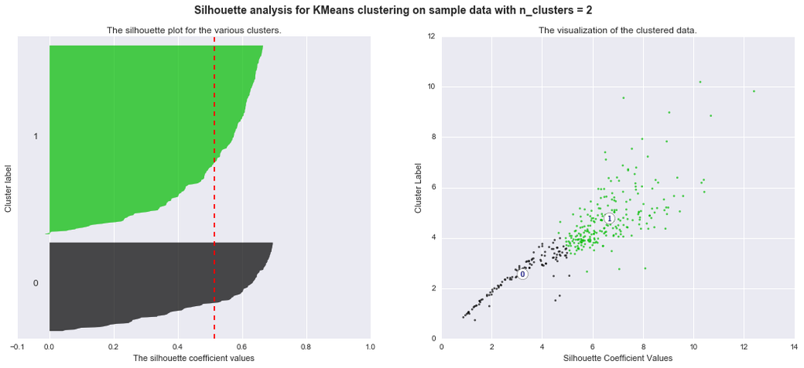

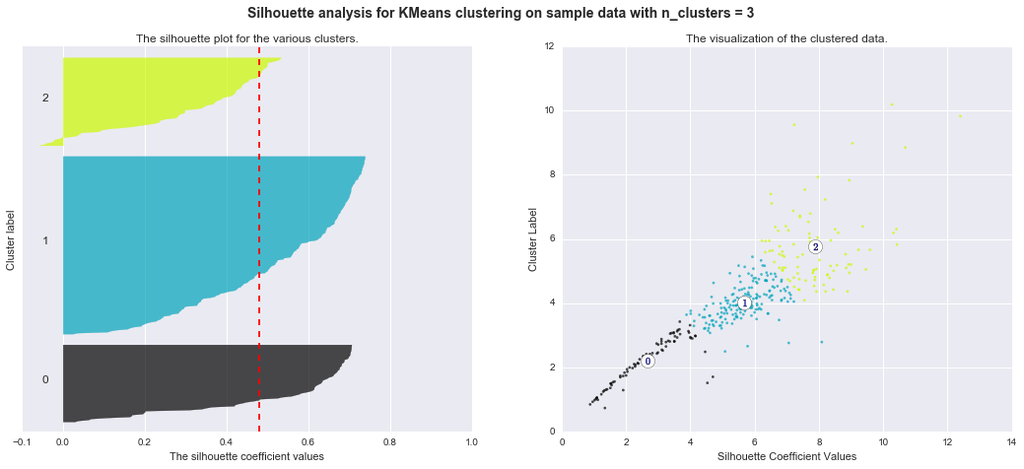

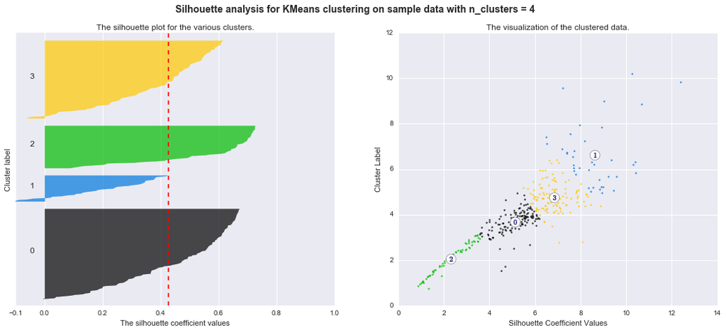

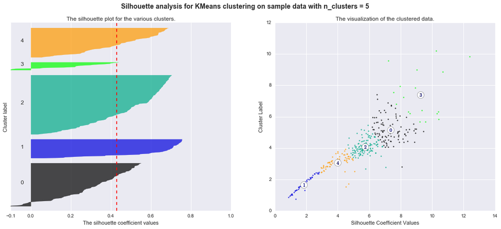

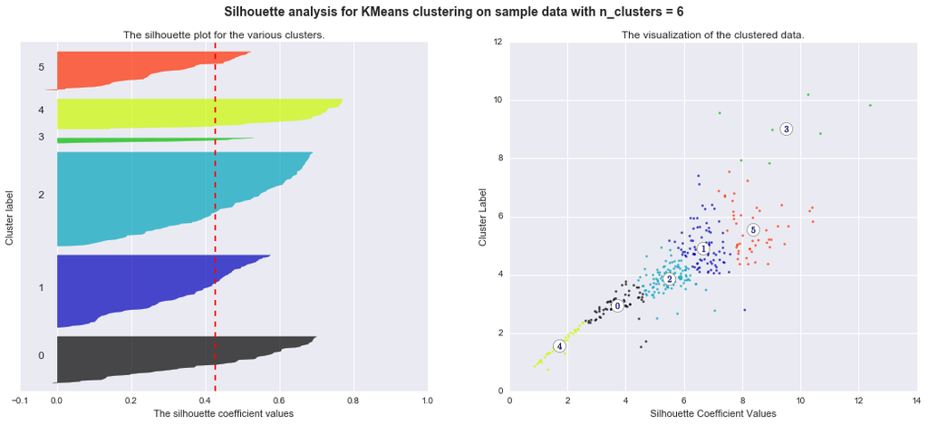

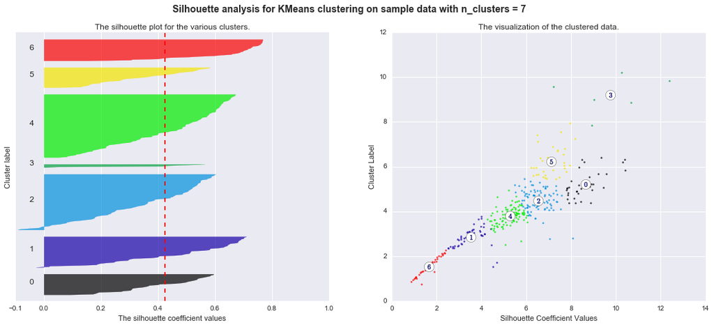

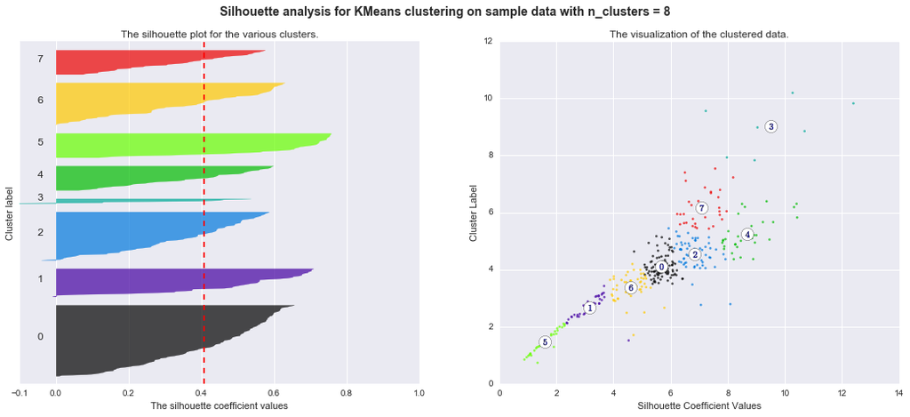

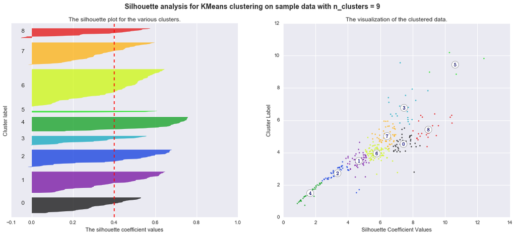

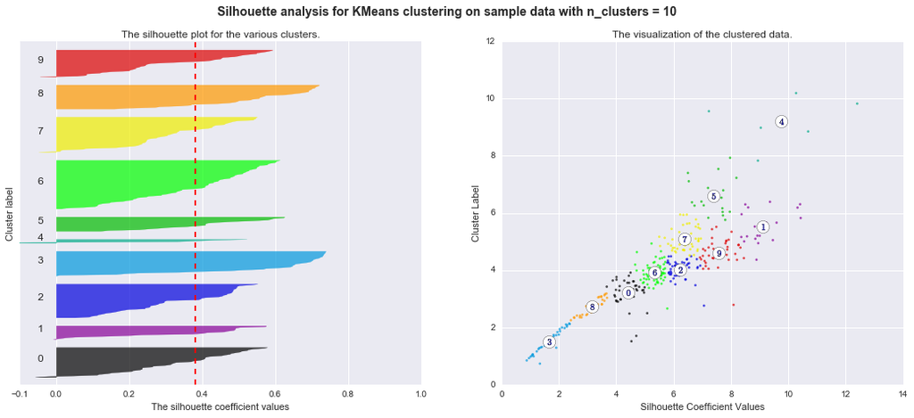

```python
# Convert the two features Coupon and YTM to numpy array
c_data = np.array(corp_df[['Coupon', 'YTM']])
data = c_data

# Loop through values for k ranging from 1 to 10 to calcualte the silhouette score
range_n_clusters = [2, 3, 4, 5, 6, 7, 8, 9, 10]

for n_clusters in range_n_clusters:
    # Create a subplot with 1 row and 2 columns
    fig, (ax1, ax2) = plt.subplots(1, 2)
    fig.set_size_inches(18, 7)

    # The 1st subplot is the silhouette plot
    # The silhouette coefficient can range from -1, 1 but in this example all
    # lie within [-0.1, 1]
    ax1.set_xlim([-0.1, 1])
    # The (n_clusters+1)*10 is for inserting blank space between silhouette
    # plots of individual clusters, to demarcate them clearly.
    ax1.set_ylim([0, len(data) + (n_clusters + 1) * 10])

    # Initialize the clusterer with n_clusters value and a random generator
    # seed of 10 for reproducibility.
    clusterer = sklearn.cluster.KMeans(n_clusters=n_clusters, random_state=10)
    cluster_labels = clusterer.fit_predict(data)

    # The silhouette_score gives the average value for all the samples.
    # This gives a perspective into the density and separation of the formed
    # clusters
    silhouette_avg = sklearn.metrics.silhouette_score(data, cluster_labels)

    # Compute the silhouette scores for each sample
    sample_silhouette_values = silhouette_samples(data, cluster_labels)

    y_lower = 10

    for i in range(n_clusters):
        # Aggregate the silhouette scores for samples belonging to
        # cluster i, and sort them
        ith_cluster_silhouette_values = \
            sample_silhouette_values[cluster_labels == i]

        ith_cluster_silhouette_values.sort()

        size_cluster_i = ith_cluster_silhouette_values.shape[0]
        y_upper = y_lower + size_cluster_i

        color = cm.spectral(float(i) / n_clusters)
        ax1.fill_betweenx(np.arange(y_lower, y_upper),
                          0, ith_cluster_silhouette_values,
                          facecolor=color, edgecolor=color, alpha=0.7)

        # Label the silhouette plots with their cluster numbers at the middle
        ax1.text(-0.05, y_lower + 0.5 * size_cluster_i, str(i))

        # Compute the new y_lower for next plot
        y_lower = y_upper + 10  # 10 for the 0 samples

    ax1.set_title("The silhouette plot for the various clusters.")
    ax1.set_xlabel("The silhouette coefficient values")
    ax1.set_ylabel("Cluster label")

    # The vertical line for average silhoutte score of all the values
    ax1.axvline(x=silhouette_avg, color="red", linestyle="--")

    ax1.set_yticks([])  # Clear the yaxis labels / ticks
    ax1.set_xticks([-0.1, 0, 0.2, 0.4, 0.6, 0.8, 1])

    # 2nd Plot showing the actual clusters formed
    colors = cm.spectral(cluster_labels.astype(float) / n_clusters)
    ax2.scatter(data[:, 0], data[:, 1], marker='.', s=30, lw=0, alpha=0.7,
                c=colors)

    # Labeling the clusters
    centers = clusterer.cluster_centers_
    # Draw white circles at cluster centers
    ax2.scatter(centers[:, 0], centers[:, 1],
                marker='o', c="white", alpha=1, s=200)

    for i, c in enumerate(centers):
        ax2.scatter(c[0], c[1], marker='$%d$' % i, alpha=1, s=50)

    ax2.set_title("The visualization of the clustered data.")
    ax2.set_xlabel("Feature space for the 1st feature")
    ax2.set_ylabel("Feature space for the 2nd feature")

    plt.suptitle(("Silhouette analysis for KMeans clustering on sample data "
                  "with n_clusters = %d" % n_clusters),
                 fontsize=14, fontweight='bold')

    plt.xlabel("Silhouette Coefficient Values")
    plt.ylabel("Cluster Label")
    plt.show()
```

#### Municipal Bonds Dataset

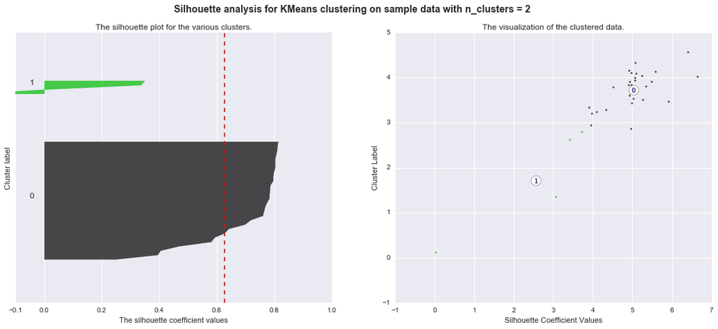

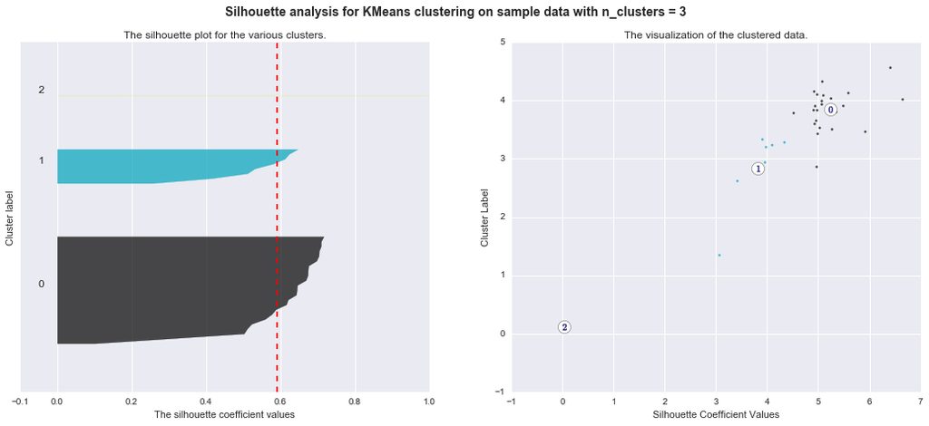

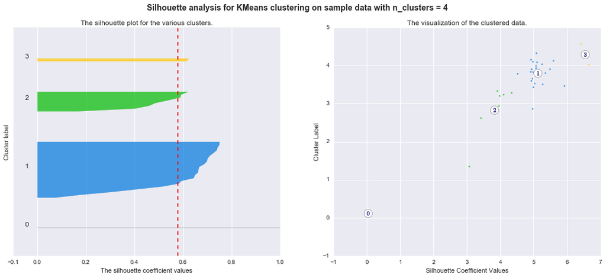

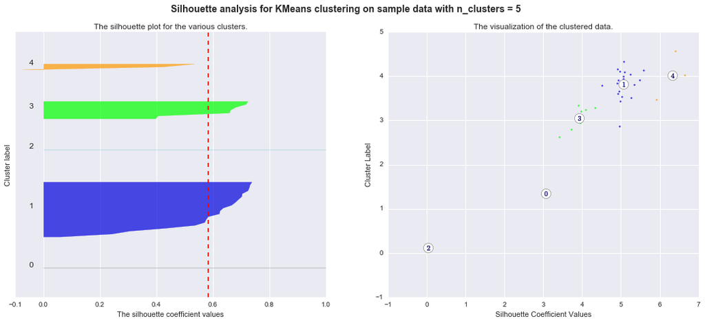

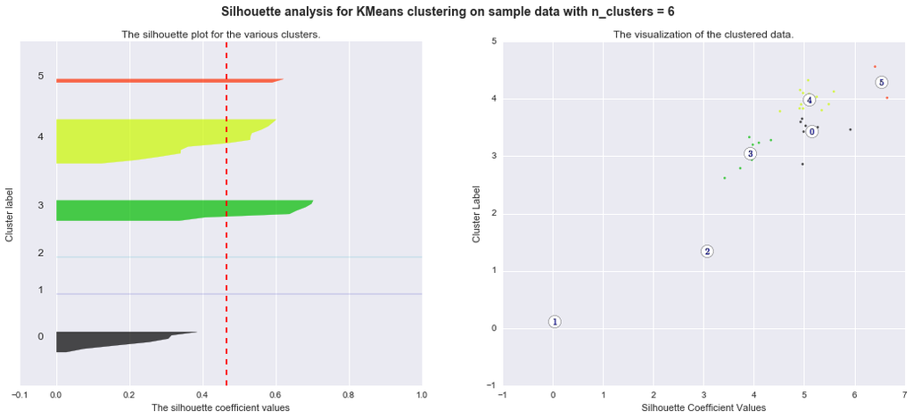

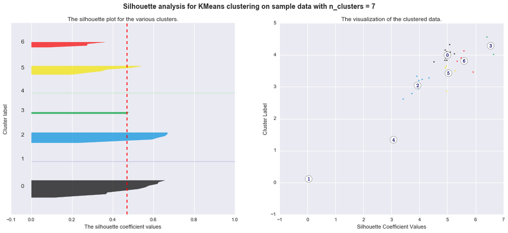

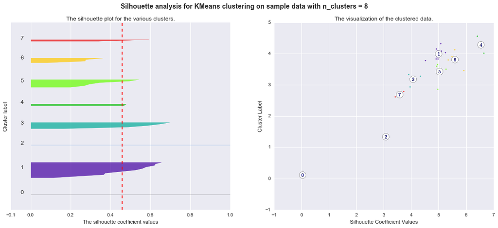

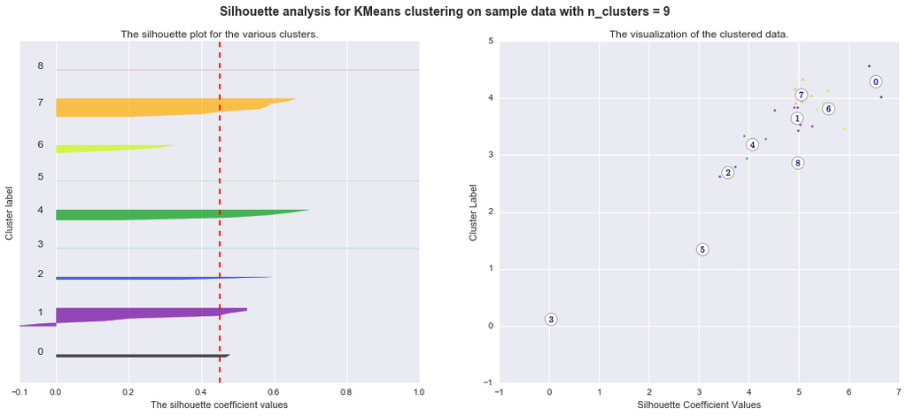

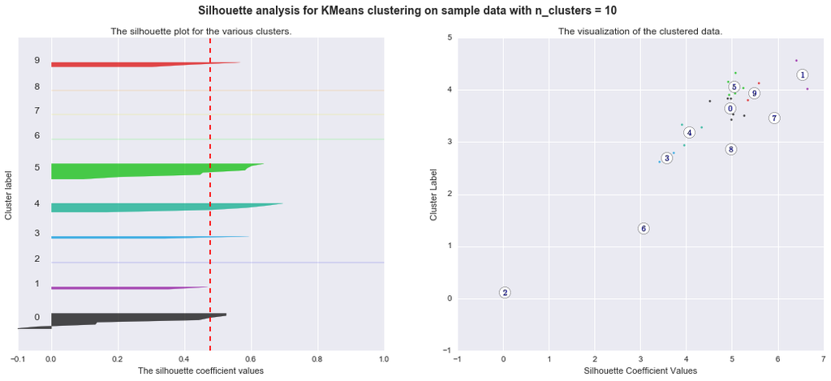

```python
# Convert the two features Coupon and YTM to numpy array
m_data = np.array(muni_df[['Coupon', 'YTM']])
data = m_data

# Loop through values for k ranging from 1 to 10 to calcualte the silhouette score
range_n_clusters = [2, 3, 4, 5, 6, 7, 8, 9, 10]

for n_clusters in range_n_clusters:
    # Create a subplot with 1 row and 2 columns
    fig, (ax1, ax2) = plt.subplots(1, 2)
    fig.set_size_inches(18, 7)

    # The 1st subplot is the silhouette plot
    # The silhouette coefficient can range from -1, 1 but in this example all
    # lie within [-0.1, 1]
    ax1.set_xlim([-0.1, 1])
    # The (n_clusters+1)*10 is for inserting blank space between silhouette
    # plots of individual clusters, to demarcate them clearly.
    ax1.set_ylim([0, len(data) + (n_clusters + 1) * 10])

    # Initialize the clusterer with n_clusters value and a random generator
    # seed of 10 for reproducibility.
    clusterer = sklearn.cluster.KMeans(n_clusters=n_clusters, random_state=10)
    cluster_labels = clusterer.fit_predict(data)

    # The silhouette_score gives the average value for all the samples.
    # This gives a perspective into the density and separation of the formed
    # clusters
    silhouette_avg = sklearn.metrics.silhouette_score(data, cluster_labels)

    # Compute the silhouette scores for each sample
    sample_silhouette_values = silhouette_samples(data, cluster_labels)

    y_lower = 10

    for i in range(n_clusters):
        # Aggregate the silhouette scores for samples belonging to
        # cluster i, and sort them
        ith_cluster_silhouette_values = \
            sample_silhouette_values[cluster_labels == i]

        ith_cluster_silhouette_values.sort()

        size_cluster_i = ith_cluster_silhouette_values.shape[0]
        y_upper = y_lower + size_cluster_i

        color = cm.spectral(float(i) / n_clusters)
        ax1.fill_betweenx(np.arange(y_lower, y_upper),
                          0, ith_cluster_silhouette_values,
                          facecolor=color, edgecolor=color, alpha=0.7)

        # Label the silhouette plots with their cluster numbers at the middle
        ax1.text(-0.05, y_lower + 0.5 * size_cluster_i, str(i))

        # Compute the new y_lower for next plot
        y_lower = y_upper + 10  # 10 for the 0 samples

    ax1.set_title("The silhouette plot for the various clusters.")
    ax1.set_xlabel("The silhouette coefficient values")
    ax1.set_ylabel("Cluster label")

    # The vertical line for average silhoutte score of all the values
    ax1.axvline(x=silhouette_avg, color="red", linestyle="--")

    ax1.set_yticks([])  # Clear the yaxis labels / ticks
    ax1.set_xticks([-0.1, 0, 0.2, 0.4, 0.6, 0.8, 1])

    # 2nd Plot showing the actual clusters formed
    colors = cm.spectral(cluster_labels.astype(float) / n_clusters)
    ax2.scatter(data[:, 0], data[:, 1], marker='.', s=30, lw=0, alpha=0.7,
                c=colors)

    # Labeling the clusters
    centers = clusterer.cluster_centers_
    # Draw white circles at cluster centers
    ax2.scatter(centers[:, 0], centers[:, 1],
                marker='o', c="white", alpha=1, s=200)

    for i, c in enumerate(centers):
        ax2.scatter(c[0], c[1], marker='$%d$' % i, alpha=1, s=50)

    ax2.set_title("The visualization of the clustered data.")
    ax2.set_xlabel("Feature space for the 1st feature")
    ax2.set_ylabel("Feature space for the 2nd feature")

    plt.suptitle(("Silhouette analysis for KMeans clustering on sample data "
                  "with n_clusters = %d" % n_clusters),
                 fontsize=14, fontweight='bold')

    plt.xlabel("Silhouette Coefficient Values")
    plt.ylabel("Cluster Label")
    plt.show()
```

### Q5: Interpreatation and Analysis of Clustering

#### Interpreting The Silhouette Score

In Q2 is the numerical output of the computed Silhouette Coefficient of all samples on both datasets.

The Silhouette Coefficient is calculated as follows: [(2)-(1)]/max{(1); (2)} Where (1) and (2) are given by:

```
1. mean intra-cluster distance
2. mean nearest-cluster distance
```

The score range is [-1 ; 1] and can be interpreted as follows:

```
* ~ -1 : negative values indicate that a sample has been assigned to the wrong cluster
* ~  0 : samples are close to the decision boundary of which cluster they should be assigned to
* ~ +1 : samples are far away from the neighboring clusters
```

#### Our Results

Given that a higher Silhouette Score is more desireable. The results for our datasets, given we have used the euclidean distance metric, indicate that 2 is the optimal value of clusters for both Corporate and Municipal Bonds.

The thickness of the silhouette plot visualise the relative size of the clusters. A similar conclusion can be reached from looking at the silhouette plots that show:

```
* n_clusters > 3 should be avoided for the Corporate Bonds dataset
* n_clusters > 4 should be avoided for the Municipal Bonds dataset
```

due to the presence of clusters with below average and sometimes negative silhouette scores and also due to wide fluctuations in the size of the silhouette plots.

#### Optimal Solution

How many clusters do you have in your data is an ill-posed question on its own. It depends on what you want to do with the data. Given the nature of our data, and the features used to cluster the it in the above analysis, it makes practical sense to give investors options in terms of risk and return. This combined with the the above analysis I would assume the best answer to number of of clusters to be 3 for the Corporate and Municipal Bonds. Allowing investors to easily self select the level of risk they are willing to take on.

## Part III - Hierarchical clustering of bond data

### Q1 - Cluster Linkage

#### Corporate Bond Dataset

```python
np.set_printoptions(precision=5, suppress=True)  # suppress scientific float notation

c_data = np.array(corp_df[['Coupon', 'YTM']])

# Generate the linkage matrices for different combinations of linkage type and distance metrics
# Distance metrics: Euclidean and Squared Euclidean
# Linkage type: Single and Weighted
Z_eucl_sgle = linkage(c_data, method='single', metric='euclidean')
Z_eucl_wght = linkage(c_data, method='weighted', metric='euclidean')
Z_sqeucl_sgle = linkage(c_data, method='single', metric='sqeuclidean')
Z_sqeucl_wght = linkage(c_data, method='weighted', metric='sqeuclidean')
```

```python
# Looking at the first 5 iterations
Z_eucl_sgle[:5]  # the resulting array has the format [idx1, idx2, dist, sample_count]
```

```
array([[ 315.     ,  316.     ,    0.002  ,    2.     ],
       [ 206.     ,  225.     ,    0.005  ,    2.     ],
       [  42.     ,  253.     ,    0.01   ,    2.     ],
       [ 331.     ,  338.     ,    0.01005,    2.     ],
       [  75.     ,  311.     ,    0.01044,    2.     ]])
```

#### Municiapl Bond Dataset

```python
np.set_printoptions(precision=5, suppress=True)  # suppress scientific float notation

c_data = np.array(muni_df[['Coupon', 'YTM']])

# Generate the linkage matrices for different combinations of linkage type and distance metrics
# Distance metrics: Euclidean and Squared Euclidean
# Linkage type: Single and Weighted
Z_eucl_sgle = linkage(c_data, method='single', metric='euclidean')
Z_eucl_wght = linkage(c_data, method='weighted', metric='euclidean')
Z_sqeucl_sgle = linkage(c_data, method='single', metric='sqeuclidean')
Z_sqeucl_wght = linkage(c_data, method='weighted', metric='sqeuclidean')
```

```python
# Looking at the first 5 iterations
Z_eucl_sgle[:5]  # the resulting array has the format [idx1, idx2, dist, sample_count]
```

```
array([[  3.     ,  22.     ,   0.058  ,   2.     ],
       [  5.     ,  27.     ,   0.06265,   2.     ],
       [ 20.     ,  31.     ,   0.07003,   2.     ],
       [ 19.     ,  34.     ,   0.07616,   3.     ],
       [  6.     ,  30.     ,   0.0794 ,   2.     ]])
```

### Q2: Generate Dendrogram of Binary Cluster Tree

#### Corporate Bond Dataset

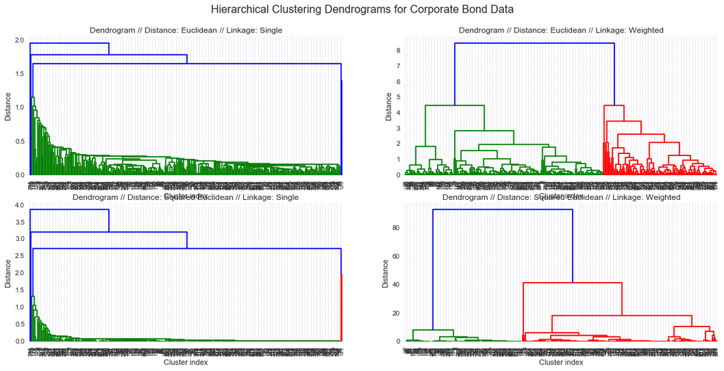

```python
# Set the frame for the whole Plot
fig = plt.figure(figsize=(18,8), dpi=1800)
fig.suptitle("Hierarchical Clustering Dendrograms for Corporate Bond Data", fontsize=16)


# Compute dendrogram for: // Distance: Euclidean // Linkage: Single
ax1 = fig.add_subplot(2, 2, 1) # rows, columns, plot nb.
dendrogram(
    Z_eucl_sgle,
    leaf_rotation=90.,  # rotates the x axis labels
    leaf_font_size=8.,  # font size for the x axis labels
)
ax1.set_title('Dendrogram // Distance: Euclidean // Linkage: Single')
ax1.set_xlabel('Cluster index')
ax1.set_ylabel('Distance')

# Compute dendrogram for: // Distance: Euclidean // Linkage: Weighted
ax2 = fig.add_subplot(2, 2, 2) # rows, columns, plot nb.
dendrogram(
    Z_eucl_wght,
    leaf_rotation=90.,  # rotates the x axis labels
    leaf_font_size=8.,  # font size for the x axis labels
)
ax2.set_title('Dendrogram // Distance: Euclidean // Linkage: Weighted')
ax2.set_xlabel('Cluster index')
ax2.set_ylabel('Distance')

# Compute dendrogram for: // Distance: Squared Euclidean // Linkage: Single
ax3 = fig.add_subplot(2, 2, 3) # rows, columns, plot nb.
dendrogram(
    Z_sqeucl_sgle,
    leaf_rotation=90.,  # rotates the x axis labels
    leaf_font_size=8.,  # font size for the x axis labels
)
ax3.set_title('Dendrogram // Distance: Squared Euclidean // Linkage: Single')
ax3.set_xlabel('Cluster index')
ax3.set_ylabel('Distance')


# Compute dendrogram for: // Distance: Squared Euclidean // Linkage: Weighted
ax4 = fig.add_subplot(2, 2, 4) # rows, columns, plot nb.
dendrogram(
    Z_sqeucl_wght,
    leaf_rotation=90.,  # rotates the x axis labels
    leaf_font_size=8.,  # font size for the x axis labels
)
ax4.set_title('Dendrogram // Distance: Squared Euclidean // Linkage: Weighted')
ax4.set_xlabel('Cluster index')
ax4.set_ylabel('Distance')


# fig.tight_layout()
plt.show()
```

The x axis are labeled with the indices of the data samples. The y axis shows the measured distances. The height of the vertical line upt to a horizontal line tells us about the distance at which this cluster was merged into another cluster. So horizontal lines are cluster merges.

#### Municiapl Bond Dataset

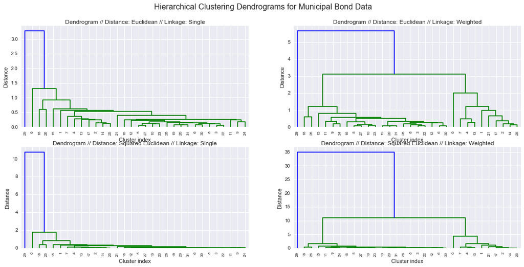

```python
# Set the frame for the whole Plot
fig = plt.figure(figsize=(18,8), dpi=1800)
fig.suptitle("Hierarchical Clustering Dendrograms for Municipal Bond Data", fontsize=16)


# Compute dendrogram for: // Distance: Euclidean // Linkage: Single
ax1 = fig.add_subplot(2, 2, 1) # rows, columns, plot nb.
dendrogram(
    Z_eucl_sgle,
    leaf_rotation=90.,  # rotates the x axis labels
    leaf_font_size=8.,  # font size for the x axis labels
)
ax1.set_title('Dendrogram // Distance: Euclidean // Linkage: Single')
ax1.set_xlabel('Cluster index')
ax1.set_ylabel('Distance')

# Compute dendrogram for: // Distance: Euclidean // Linkage: Weighted
ax2 = fig.add_subplot(2, 2, 2) # rows, columns, plot nb.
dendrogram(
    Z_eucl_wght,
    leaf_rotation=90.,  # rotates the x axis labels
    leaf_font_size=8.,  # font size for the x axis labels
)
ax2.set_title('Dendrogram // Distance: Euclidean // Linkage: Weighted')
ax2.set_xlabel('Cluster index')
ax2.set_ylabel('Distance')

# Compute dendrogram for: // Distance: Squared Euclidean // Linkage: Single
ax3 = fig.add_subplot(2, 2, 3) # rows, columns, plot nb.
dendrogram(
    Z_sqeucl_sgle,
    leaf_rotation=90.,  # rotates the x axis labels
    leaf_font_size=8.,  # font size for the x axis labels
)
ax3.set_title('Dendrogram // Distance: Squared Euclidean // Linkage: Single')
ax3.set_xlabel('Cluster index')
ax3.set_ylabel('Distance')


# Compute dendrogram for: // Distance: Squared Euclidean // Linkage: Weighted
ax4 = fig.add_subplot(2, 2, 4) # rows, columns, plot nb.
dendrogram(
    Z_sqeucl_wght,
    leaf_rotation=90.,  # rotates the x axis labels
    leaf_font_size=8.,  # font size for the x axis labels
)
ax4.set_title('Dendrogram // Distance: Squared Euclidean // Linkage: Weighted')
ax4.set_xlabel('Cluster index')
ax4.set_ylabel('Distance')


# fig.tight_layout()
plt.show()
```

### Q3: Interpreting Results

##### incl. Bonus Question

The same linkage method produces similar results for the distance metric 'euclidean' and 'sqeuclidean'. Although is not very suprising. Even less so by the fact that the one outlier that was present in the corporate dataset was removed that might have impacted the squared euclidean in particular.

The differences become more apparent when looking at the two different linkage methods: 'single' vs 'weighted'. It seems the single method in particular has had difficultiessplitting the data into two clusters of similar size. The weighted method on the otherhand that averages the pairwise distances has been more efficient in this.

From the above dendrograms it appears the best combination of distance metric and linkage method is the euclidean with the weighted linkage. We should note that our results might be quite different should we explore different features of the dataset or even different distance metrics and linkage methods.

For the same reasons that were discussed in the last section, the nature of the data should be considered when determining a "reasonable" number of clusters. Since we are still assessing the same data and the outcomes in this BOTTOM-UP analysis yielded similar results I still believe 2-3 are the right number of cluster for the corporate and municipal bonds datasets.